# Dipping toes in Mixed Effects Modelling in R

R markdown tutorial - among thousands of them out there I (almost randomly) picked this one : https://r4ds.had.co.nz/r-markdown.html

```r
library(tidyverse)
library(viridis)
library(glue)
```

press Crtl+Alt+i and see what happens

I am pretty much repeating what these web resources have to say about Mixed Effects Modelling: https://ourcodingclub.github.io/2017/03/15/mixed-models.html https://web.stanford.edu/class/psych252/section/Mixed_models_tutorial.html https://cran.r-project.org/web/packages/lme4/vignettes/lmer.pdf

### grab the data and take a look

Crtl+Shift+Enter and see what happens

```r
load("dragons.Rdata")
head(dragons)
```

|  | testScore | bodyLength | mountainRange | X | site |
| --- | --- | --- | --- | --- | --- |
| 1 | 16.147309 | 165.5485 | Bavarian | NA | a |
| 2 | 33.886183 | 167.5593 | Bavarian | NA | a |
| 3 | 6.038333 | 165.8830 | Bavarian | NA | a |
| 4 | 18.838821 | 167.6855 | Bavarian | NA | a |
| 5 | 33.862328 | 169.9597 | Bavarian | NA | a |
| 6 | 47.043246 | 168.6887 | Bavarian | NA | a |

```r
str(dragons)
```

```
## 'data.frame':    480 obs. of  5 variables:
##  $ testScore    : num  16.15 33.89 6.04 18.84 33.86 ...
##  $ bodyLength   : num  166 168 166 168 170 ...
##  $ mountainRange: Factor w/ 8 levels "Bavarian","Central",..: 1 1 1 1 1 1 1 1 1 1 ...
##  $ X            : logi  NA NA NA NA NA NA ...
##  $ site         : Factor w/ 3 levels "a","b","c": 1 1 1 1 1 1 1 1 1 1 ...
```

# First thing first, visualize your data!

How’s your outcome variable look like?

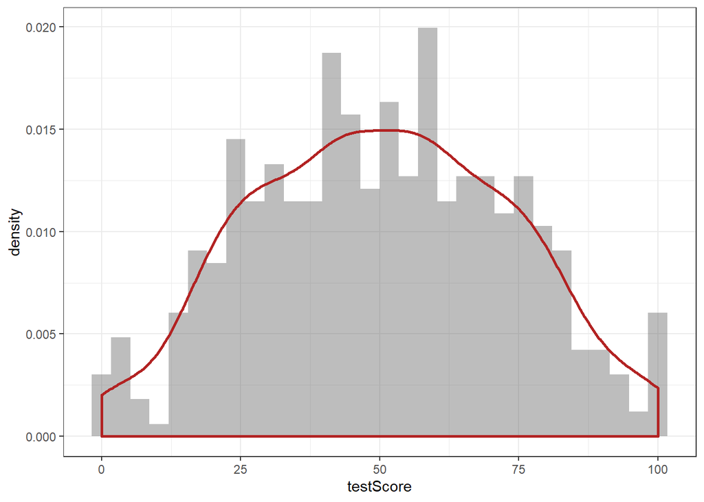

```r
dragons %>%
  ggplot(.,aes(testScore)) +
  geom_histogram(aes(y =..density..),alpha = .4)+
  geom_density(col="firebrick",size=1)+
  theme_bw()
```

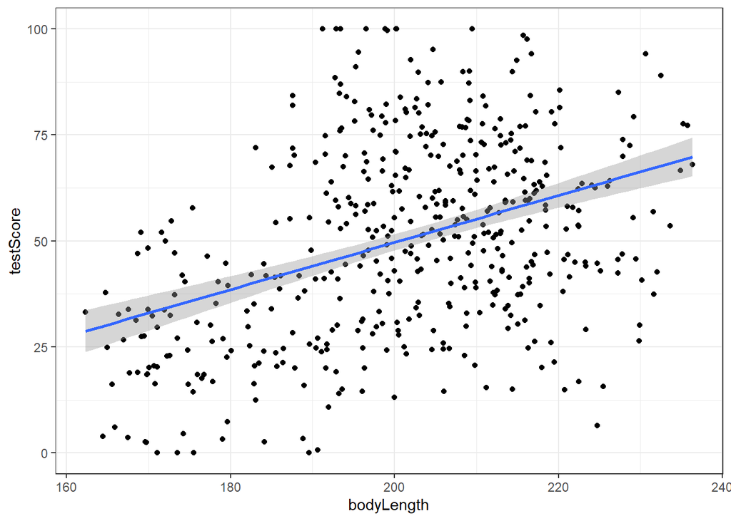

```r
dragons %>%
  ggplot(.,aes(x = bodyLength, y = testScore)) +
  geom_point() +
  geom_smooth(method = "lm")+
  theme_bw()
```

### Linear regression

```r
basic.lm <- lm(testScore ~ bodyLength, data = dragons)
summary(basic.lm)
```

```
##
## Call:
## lm(formula = testScore ~ bodyLength, data = dragons)
##
## Residuals:
##     Min      1Q  Median      3Q     Max
## -56.962 -16.411  -0.783  15.193  55.200
##
## Coefficients:
##              Estimate Std. Error t value Pr(>|t|)
## (Intercept) -61.31783   12.06694  -5.081 5.38e-07 ***
## bodyLength    0.55487    0.05975   9.287  < 2e-16 ***
## ---
## Signif. codes:  0 '***' 0.001 '**' 0.01 '*' 0.05 '.' 0.1 ' ' 1
##
## Residual standard error: 21.2 on 478 degrees of freedom
## Multiple R-squared:  0.1529, Adjusted R-squared:  0.1511
## F-statistic: 86.25 on 1 and 478 DF,  p-value: < 2.2e-16
```

Is your model good looking?

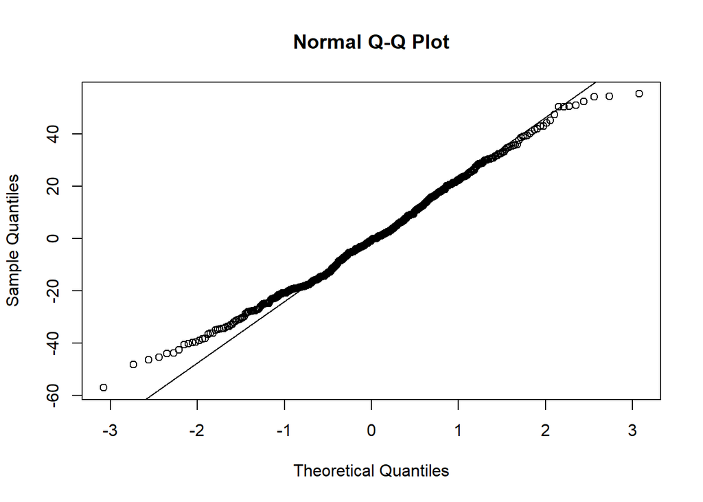

```r
qqnorm(resid(basic.lm))
qqline(resid(basic.lm))
```

## Mixed effects modeling

#### Use facet_wrap(~variable) or facet_grid(variable1~variable2)

Information we haven’t utilize: Mountain range, site

Again, know your data!

```r
table(dragons$site,dragons$mountainRange)
```

```
##
##     Bavarian Central Emmental Julian Ligurian Maritime Sarntal Southern
##   a       20      20       20     20       20       20      20       20
##   b       20      20       20     20       20       20      20       20
##   c       20      20       20     20       20       20      20       20
```

```r
dragons <- dragons %>%
  mutate(sampling_site = glue('{mountainRange}_{site}'))
head(dragons)
```

|  | testScore | bodyLength | mountainRange | X | site | sampling_site |
| --- | --- | --- | --- | --- | --- | --- |
| 1 | 16.147309 | 165.5485 | Bavarian | NA | a | Bavarian_a |
| 2 | 33.886183 | 167.5593 | Bavarian | NA | a | Bavarian_a |
| 3 | 6.038333 | 165.8830 | Bavarian | NA | a | Bavarian_a |
| 4 | 18.838821 | 167.6855 | Bavarian | NA | a | Bavarian_a |
| 5 | 33.862328 | 169.9597 | Bavarian | NA | a | Bavarian_a |
| 6 | 47.043246 | 168.6887 | Bavarian | NA | a | Bavarian_a |

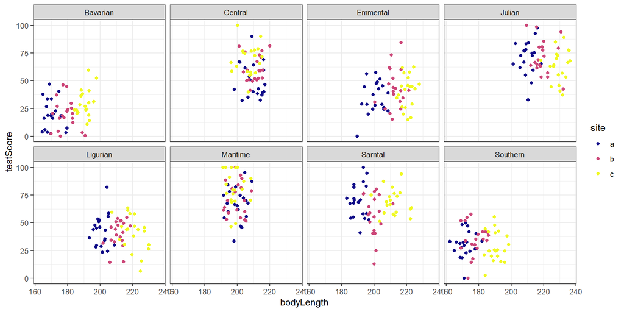

```r
dragons %>%
  ggplot(.,aes(bodyLength,testScore,col=site))+
  geom_point()+
  facet_wrap(~mountainRange,ncol=4)+
  theme_bw()+
  scale_color_viridis(discrete = T, option = "C")
```

Alternatively. But I do prefer using facet_wrap()

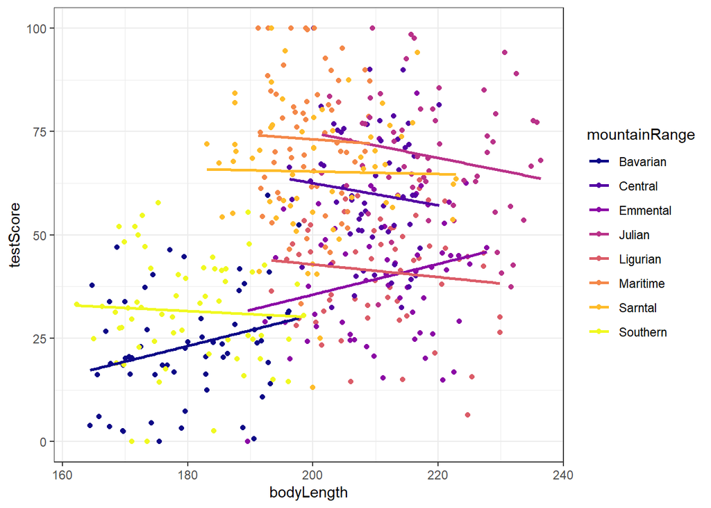

```r
dragons %>%
  ggplot(.,aes(bodyLength,testScore,col=mountainRange))+
  geom_point()+
  geom_smooth(method = "lm", se=FALSE)+
  theme_bw()+
  scale_color_viridis(discrete = T, option = "C")
```